# Week 5 Day 2 Homework

## Load in the libraries you need, and look at the backpack data. Take note of variable names and dimensions.

```r
library(CodeClanData)

library(tidyverse)
```

```r
backpack <- backpack

glimpse(backpack)
```

```
Rows: 100
Columns: 9
$ backpack_weight <int> 9, 8, 10, 6, 8, 5, 8, 4, 5, 2, 8, 21, 11, 11, 12, 11, 13, 6, 10, 5, 20, 1…
$ body_weight     <int> 125, 195, 120, 155, 180, 240, 170, 185, 130, 120, 135, 160, 170, 170, 125…
$ ratio           <dbl> 0.0720000, 0.0410256, 0.0833333, 0.0387097, 0.0444444, 0.0208333, 0.04705…
$ back_problems   <int> 1, 0, 1, 0, 0, 0, 0, 1, 0, 0, 0, 0, 0, 1, 1, 0, 1, 0, 1, 0, 0, 1, 0, 0, 0…
$ major           <fct> Bio, Philosophy, GRC, CSC, EE, History, CM, ARCE, Bio, Bio, Bus, ME, CPE,…
$ year            <int> 3, 5, 4, 6, 2, 0, 3, 5, 4, 5, 3, 5, 4, 4, 3, 4, 4, 3, 3, 3, 2, 2, 5, 5, 3…
$ sex             <fct> Female, Male, Female, Male, Female, Male, Male, Female, Female, Female, F…
$ status          <fct> U, U, U, G, U, G, U, U, U, U, U, U, U, U, U, U, U, U, U, U, U, U, U, U, U…
$ units           <int> 13, 12, 14, 0, 14, 0, 15, 18, 14, 8, 15, 12, 16, 16, 12, 16, 16, 16, 17, …
```

```r
colSums(is.na(backpack))
```

```
backpack_weight     body_weight           ratio   back_problems           major            year
              0               0               0               0               0               0
            sex          status           units
              0               0               0
```

```r
backpack %>%
distinct(backpack_weight)
```

| backpack_weight |
| --- |
| 9 |
| 8 |
| 10 |
| 6 |
| 5 |
| 4 |
| 2 |
| 21 |
| 11 |
| 12 |

[output cut: 12 more lines]

## What is the distribution of backpack weights that students are carrying? Choose an appropriate graph to show the distribution.

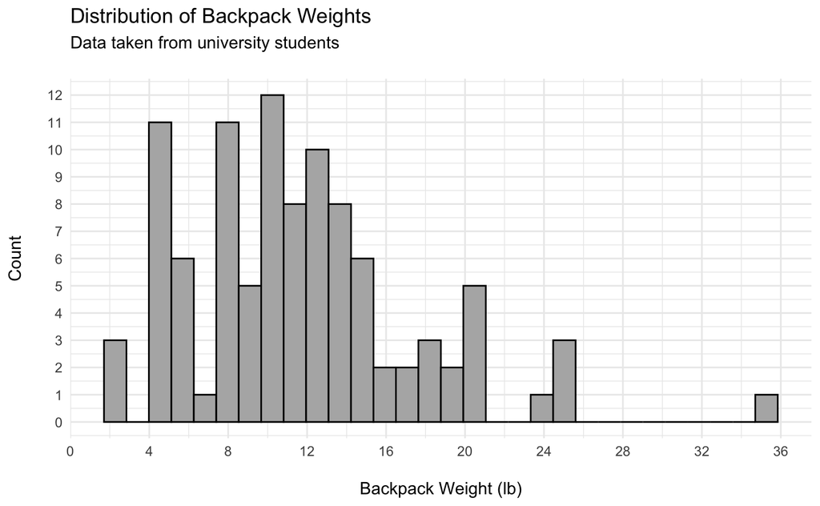

```r
ggplot(backpack) +
  aes(x = backpack_weight) +
  geom_histogram(fill = "grey70", col = "black") +
  theme_minimal() +
  labs(
    x = "\nBackpack Weight (lb)",
    y = "Count\n",
    title = "Distribution of Backpack Weights",
    subtitle = "Data taken from university students\n"
  ) +
  scale_y_continuous(breaks = seq(from = 0, to = 13, by = 1)) +
  scale_x_continuous(breaks = seq(from = 0, to = 36, by = 4))
```

The plot above shows how backpack weights are distributed by the number of students backpacks that weighed that amount. From the data we can see the backpacks mostly weigh in between about 5 and 15 lbs.

## Are there differences in backpack weight between sex?

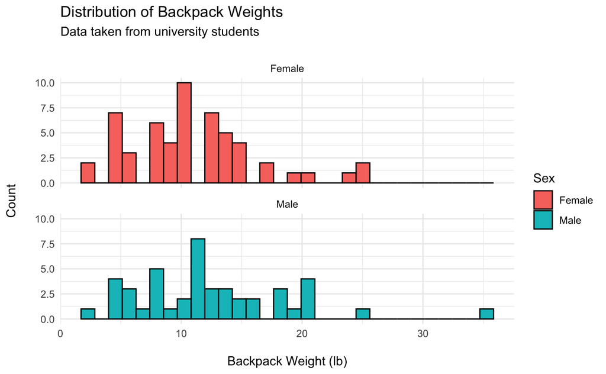

```r
ggplot(backpack) +
  aes(x = backpack_weight,
      fill = sex) +
  geom_histogram( col = "black") +
  theme_minimal() +
  facet_wrap(~sex, ncol = 1) +
  labs(
    x = "\nBackpack Weight (lb)",
    y = "Count\n",
    title = "Distribution of Backpack Weights",
    subtitle = "Data taken from university students\n",
    fill = "Sex"
  )
```

From the plot above we can see that there is no real difference in the distribution of backpack weights between genders

## What is the relationship between body weight and backpack weight?

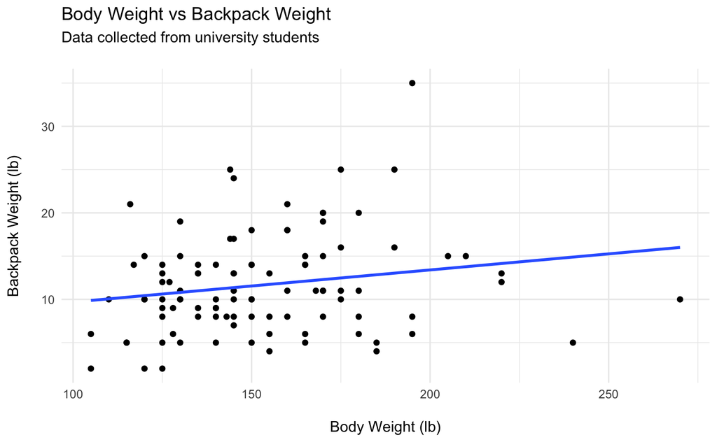

```r
ggplot(backpack) +
  aes(x = body_weight,
      y = backpack_weight) +
  geom_point() +
  geom_smooth(method = "lm",
              se = FALSE) +
  theme_minimal() +
  labs(
    x = "\nBody Weight (lb)",
    y = "Backpack Weight (lb)\n",
    title = "Body Weight vs Backpack Weight",
    subtitle = "Data collected from university students\n"
  )
```

```r
NA
NA
```

There is a weak positive correlation between the body weight of a student and their backpack weights

## Is this relationship different between men and women? Choose an appropriate

plot and interpret your findings.

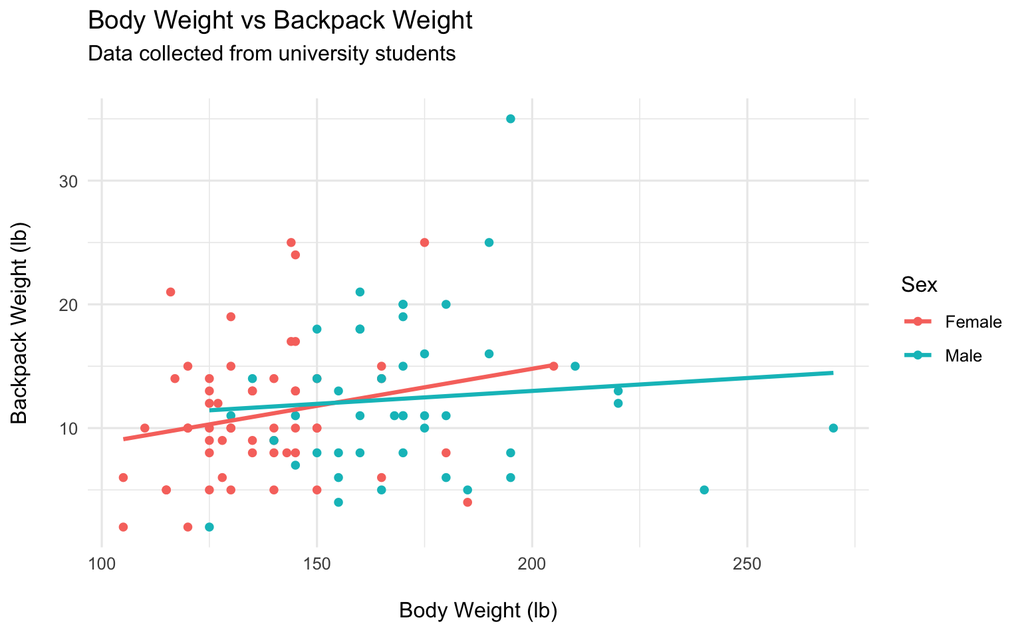

```r
ggplot(backpack) +
  aes(x = body_weight,
      y = backpack_weight,
      colour = sex) +
  geom_point() +
  geom_smooth(method = "lm",
              se = FALSE) +
  theme_minimal() +
  labs(
    x = "\nBody Weight (lb)",
    y = "Backpack Weight (lb)\n",
    title = "Body Weight vs Backpack Weight",
    subtitle = "Data collected from university students\n",
    colour = "Sex"
  )
```

There is a slightly stronger correlation between womens body weights and backpack weights when compared to mens. However, neither are strong enough to draw conclusions from

## What proportion of students report back pain?

```r
backpack %>%
  filter(back_problems == 1) %>%
  nrow() / 100
```

```
[1] 0.32
```

0.32 is the proportion of students suffering with back pain

## Is this proportion different between men and women?

```r
males <- backpack %>%
  filter((sex == "Male")) %>%
  nrow()


males_backpain_proportion <- backpack %>%
  filter((back_problems == 1) & (sex == "Male")) %>%
  nrow() / (males)

males_backpain_proportion
```

```
[1] 0.1777778
```

0.18 is the proportion of men suffering from back pain

```r
females<- backpack %>%
  filter((sex == "Female")) %>%
  nrow()


females_backpain_proportion <- backpack %>%
  filter((back_problems == 1) & (sex == "Female")) %>%
  nrow() / (females)

females_backpain_proportion
```

```
[1] 0.4363636
```

0.44 is the proportion of women who suffer from backpain.

## Now you’ve investigated your data separately, create plots to describe the

relationship between backpack weight, body weight, gender and reported backpain.

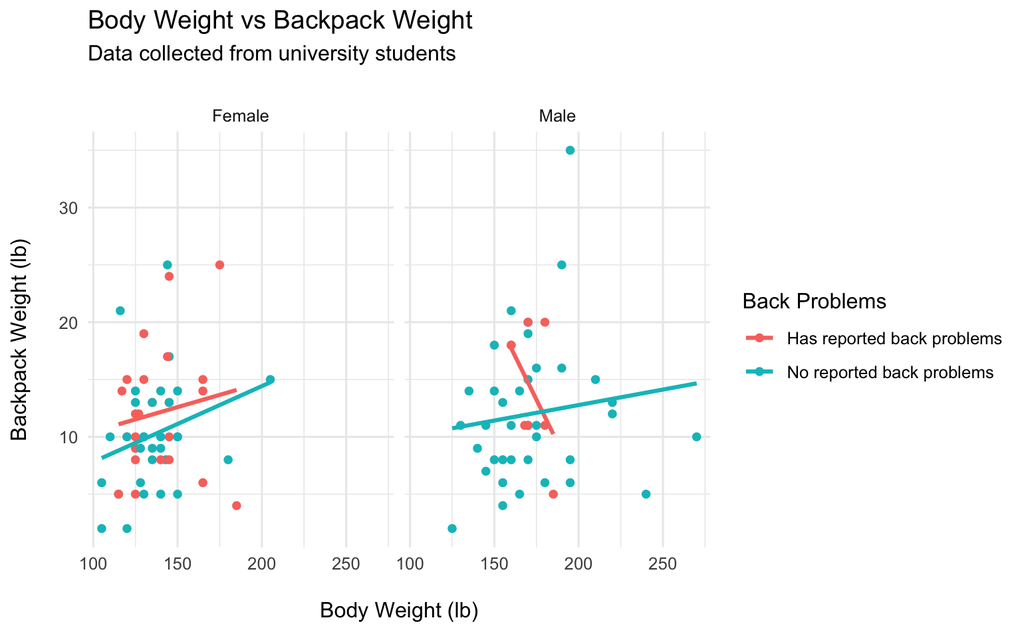

```r
backpack %>%
  mutate(back_problems = case_when(
    back_problems == 0 ~ "No reported back problems",
    back_problems == 1 ~ "Has reported back problems"
  )) %>%
ggplot() +
  aes(x = body_weight,
      y = backpack_weight,
      colour = as.factor(back_problems)) +
  geom_point() +
  geom_smooth(method = "lm",
              se = FALSE) +
  facet_wrap(~sex) +
  theme_minimal() +
  labs(
    x = "\nBody Weight (lb)",
    y = "Backpack Weight (lb)\n",
    title = "Body Weight vs Backpack Weight",
    subtitle = "Data collected from university students\n",
    colour = "Back Problems"
  )
```

For females there is a slightly stronger correlation between backpack weight and body weight compared to men. However neither are convincing enough to draw conclusions from. There doesnt seem to be much correlation between backpack weigh vs body weight with regards to whether a student has reported experiencing back pain.

## Does reported backpain differ across the year groups? Ignore year 0 in your

data.

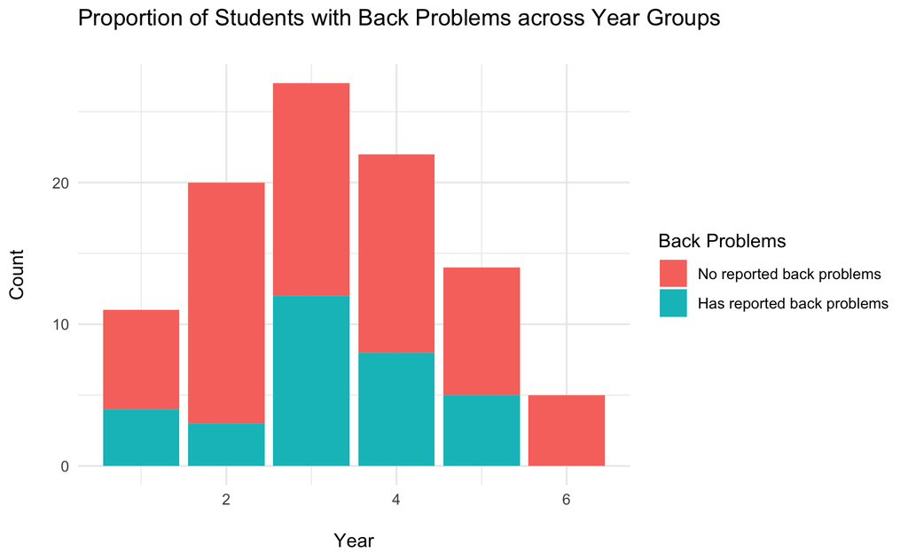

```r
ggplot(backpack) +
  aes(x = year,
      fill = as.factor(back_problems)) +
  geom_bar(data = subset(backpack, year != 0)) +
  scale_fill_discrete(labels = c("No reported back problems",
                                 "Has reported back problems")) +
  labs(
    y = "Count\n",
    x = "\nYear",
    fill = "Back Problems",
    title = "Proportion of Students with Back Problems across Year Groups\n"
  ) +
  theme_minimal()
```

## Is there a difference between how heavy the bags those in different years

## carry?

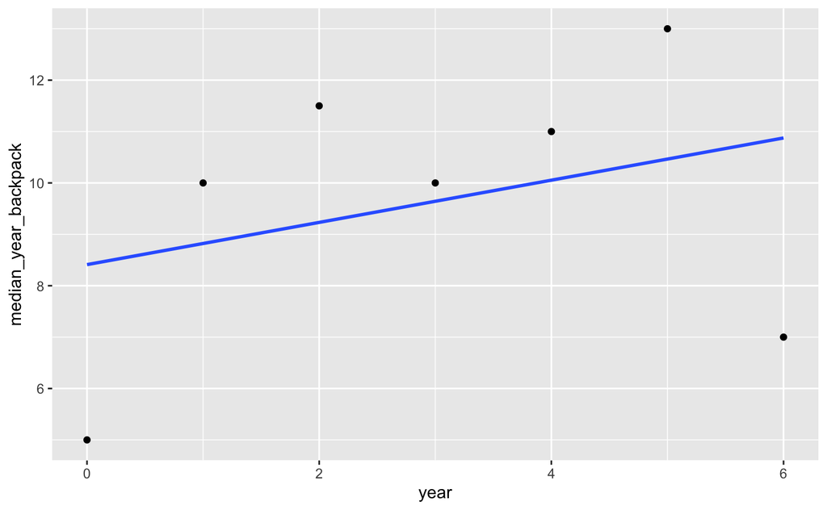

```r
backpack %>%
  group_by(year) %>%
  summarise(median_year_backpack = median(backpack_weight)) %>%
ggplot() +
  aes(y = median_year_backpack,
      x = year) +
  geom_point() +
  geom_smooth(method = "lm", se = FALSE)
```

Looking at the graph above I don’t see any correlation between the year of the student and how heavy their backpack is.